# CG3201 Project 1 — Binary Classification with Soft-Margin SVM and Kernel SVM

(Cougar-face vs Cougar-body)

Kenneth Wong Cun Wi A0303203A

# Part 1 — Dataset processing and soft-margin linear SVM (from scratch)

```python
# Setup and dependencies
from pathlib import Path
import numpy as np
import matplotlib.pyplot as plt
from PIL import Image

from project1.features import make_split
from project1.linear_svm import LinearSoftMarginSVM
from project1.kernel_svm import KernelSoftMarginSVM_SMO
from project1.metrics import accuracy, confusion_matrix_binary

from sklearn.svm import SVC
```

## Part 1(a) Data loading and feature construction

### Dataset

The dataset contains two folders:

- `caltech_cougar/cougar_face` (label $+1$)
- `caltech_cougar/cougar_body` (label $-1$)

**Train/test split**

- I use a stratified 70/30 split (i.e., `test_ratio=0.3`) with a fixed random seed so that both classes contribute the same proportion of samples to train and test.
- For hyperparameter tuning in Part 1(b), I further split the training portion into *train/validation (also stratified). The validation set is used only for selecting $(C,\text{lr},\text{epochs})$; the test set remains untouched until Part 1(c).

### Feature choice

- I use a simple gradient orientation histogram feature (`hoglike` / "HOG-inspired") plus coarse downsampled pixels. This is a practical choice to make face-vs-body separable using edge/shape cues and is often used to extract features from image data.

The intuition is that face images often contain strong local edge patterns (eyes, snout contours), while body images contain broader contours and background structure. Gradient-orientation histograms capture these edge-direction patterns more directly than raw pixels alone.

(Code is appended at the end of the pdf)

### Preprocessing used (and why)

1. **Resize to $64\times 64$ and grayscale**: standardizes input size and reduces variability from color/illumination; also fixes the feature dimension $d$.
2. **Normalize pixels to $[0,1]$**: keeps numeric ranges stable before computing gradients/concatenating features.
3. **Compute gradients $(g_x,g_y)$ and orientations**: edges are informative for shape differences (face vs body).
4. **Cell histograms (8×8 cells, 9 bins)**: aggregates local edge directions while being robust to small shifts/noise.
5. **L2-normalize the histogram vector**: reduces sensitivity to overall contrast/brightness.
6. **Concatenate coarse downsampled pixels (16×16)**: preserves rough global layout (e.g., where strong edges appear overall), complementing local histograms.
7. **Standardization using training mean/std**: important because SVM (and SGD training) is sensitive to feature scaling; must compute scaling on train only to avoid test leakage.

```python
root = Path.cwd() / 'caltech_cougar'
split = make_split(root, test_ratio=0.3, seed=0, feature_mode='hoglike')

print('Basic dataset statistics:')
print('Train samples:', split.X_train.shape[0], 'Test samples:', split.X_test.shape[0])
print('Feature dimension:', split.X_train.shape[1])
print('Train counts (+1 face, -1 body):', int(np.sum(split.y_train==1)),
      int(np.sum(split.y_train==-1)))
print('Test counts  (+1 face, -1 body):', int(np.sum(split.y_test==1)),
      int(np.sum(split.y_test==-1)))
```

```
Basic dataset statistics:
Train samples: 81 Test samples: 35
Feature dimension: 832
Train counts (+1 face, -1 body): 48 33
Test counts  (+1 face, -1 body): 21 14
```

## Part 1(b) Soft-margin linear SVM implementation

I implemented a soft-margin linear SVM (primal). The soft-margin SVM is:

$$ \min_{w,b,\varepsilon}\ \frac{1}{2}\lVert w\rVert^2 + C\sum_i \varepsilon_i \quad\text{s.t. } y_i(w^T x_i + b) \ge 1 - \varepsilon_i,\ \varepsilon_i \ge 0\ \forall i. $$

This can be written as the hinge-loss objective by using the minimal slack needed to satisfy the constraints: $$ \varepsilon_i = \max\bigl(0, 1 - y_i(w^T x_i + b)\bigr). $$ So the equivalent hinge-loss objective is:

$$ \min_{w,b}\ \frac{1}{2}\lVert w\rVert^2 + C\sum_{i} \max\bigl(0, 1 - y_i(w^T x_i + b)\bigr). $$

- The $\tfrac12\lVert w\rVert^2$ term encourages a large margin (regularization).
- The hinge-loss term penalizes margin violations or misclassifications (points with signed margin $m_i=y_i(w^Tx_i+b)<1$).

### Hyperparameter $C$

$C$ trades off margin maximization vs penalizing violations:

- Larger $C$: penalizes violations more → tends to fit training data more tightly, often resulting in a smaller margin and higher overfit risk (higher variance, lower bias).
- Smaller $C$: penalizes violations less → allows a wider margin, can underfit if too small, and is often more robust to noise/outliers (lower variance, higher bias).

### Optimization approach (SGD / subgradient)

I use stochastic subgradient descent (SGD), which was inspired by what I learnt from Lab 1:

- If $y_i(w^T x_i + b) \ge 1$, the hinge loss is 0 and only the regularizer contributes.
- Otherwise, the hinge-loss contributes a corrective term scaled by $C$.

Hyperparameters are selected via a small validation sweep over $(C, \text{learning rate}, \text{epochs})$ on the training set (test set remains untouched).

```python
'''
Code for linear_svm.py
'''
from __future__ import annotations

from dataclasses import dataclass

import numpy as np


@dataclass
class LinearSVMResult:
    w: np.ndarray
    b: float


class LinearSoftMarginSVM:
    """From-scratch soft-margin linear SVM via SGD on hinge loss + L2 regularization.

    Objective:
        min_{w,b} 1/2 ||w||^2 + C * sum_i max(0, 1 - y_i (w^T x_i + b))

    We do stochastic subgradient descent.
    """

    def __init__(self, C: float = 1.0, learning_rate: float = 1e-3, epochs: int = 50, seed: int = 0):
        self.C = float(C)
        self.learning_rate = float(learning_rate)
        self.epochs = int(epochs)
        self.seed = int(seed)
        self.w: np.ndarray | None = None
        self.b: float = 0.0

    def fit(self, X: np.ndarray, y: np.ndarray) -> "LinearSoftMarginSVM":
        X = np.asarray(X, dtype=np.float32)
        y = np.asarray(y, dtype=np.float32).reshape(-1)
        n, d = X.shape

        rng = np.random.default_rng(self.seed)
        self.w = np.zeros(d, dtype=np.float32)
        self.b = 0.0

        for _ in range(self.epochs):
            idx = rng.permutation(n)
            for i in idx:
                xi = X[i]
                yi = y[i]

                margin = yi * (float(np.dot(self.w, xi)) + self.b)

                # Subgradient for 1/2||w||^2 is w.
                if margin >= 1.0:
                    grad_w = self.w
                    grad_b = 0.0
                else:
                    grad_w = self.w - self.C * yi * xi
                    grad_b = -self.C * yi

                self.w = self.w - self.learning_rate * grad_w
                self.b = self.b - self.learning_rate * grad_b

        return self

    def decision_function(self, X: np.ndarray) -> np.ndarray:
        if self.w is None:
            raise RuntimeError("Model not fitted")
        X = np.asarray(X, dtype=np.float32)
        return X @ self.w + self.b

    def predict(self, X: np.ndarray) -> np.ndarray:
        scores = self.decision_function(X)
        return np.where(scores >= 0.0, 1, -1)
```

```
Train/test split uses test_ratio=0.3 (stratified).
Within the training portion, validation split ratio = 0.25 (stratified).
Train subset size: 61 Val subset size: 20
Best validation accuracy: 0.8
Best (C, lr, epochs): (0.1, 0.002, 200)
```

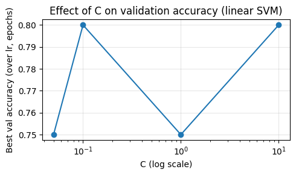

```python
# Make a small validation set from the training split (keep the test split untouched).
def stratified_split(y, val_ratio=0.25, seed=0):
    rng = np.random.default_rng(seed)
    y = np.asarray(y)
    idx_pos = np.where(y == 1)[0]
    idx_neg = np.where(y == -1)[0]
    rng.shuffle(idx_pos)
    rng.shuffle(idx_neg)
    npos_val = int(round(len(idx_pos) * val_ratio))
    nneg_val = int(round(len(idx_neg) * val_ratio))
    val_idx = np.concatenate([idx_pos[:npos_val], idx_neg[:nneg_val]])
    tr_idx = np.concatenate([idx_pos[npos_val:], idx_neg[nneg_val:]])
    rng.shuffle(val_idx)
    rng.shuffle(tr_idx)
    return tr_idx, val_idx

tr_idx, va_idx = stratified_split(split.y_train, val_ratio=0.25, seed=0)
Xtr, ytr = split.X_train[tr_idx], split.y_train[tr_idx]
Xva, yva = split.X_train[va_idx], split.y_train[va_idx]

print('Train/test split uses test_ratio=0.3 (stratified).')
print('Within the training portion, validation split ratio = 0.25 (stratified).')
print('Train subset size:', Xtr.shape[0], 'Val subset size:', Xva.shape[0])

# Sweep over a small grid to pick reasonable hyperparameters.
# Note: accuracy is discrete and the dataset is small, so multiple C values can tie in accuracy.
grid_rows = []
best = (-1.0, None)
for C in [0.05, 0.1, 1.0, 10.0]:
    for lr in [1e-3, 2e-3]:
        for epochs in [120, 200]:
            m = LinearSoftMarginSVM(C=C, learning_rate=lr, epochs=epochs, seed=0)
            m.fit(Xtr, ytr)
            va_acc = accuracy(yva, m.predict(Xva))
            grid_rows.append((C, lr, epochs, va_acc))
            if va_acc > best[0]:
                best = (va_acc, (C, lr, epochs))

print('Best validation accuracy:', best[0])
print('Best (C, lr, epochs):', best[1])

# Plot validation accuracy vs C (max over lr/epochs for each C).
Cs = sorted({r[0] for r in grid_rows})
best_by_C = [max(acc for (c, lr, ep, acc) in grid_rows if c == C) for C in Cs]

plt.figure(figsize=(5, 3))
plt.semilogx(Cs, best_by_C, marker='o')
plt.xlabel('C (log scale)')
plt.ylabel('Best val accuracy (over lr, epochs)')
plt.title('Effect of C on validation accuracy (linear SVM)')
plt.grid(True, alpha=0.3)
plt.tight_layout()
plt.show()
```

- Why $C=10^{-1}$ over $C=10^{1}$?

Both give the same validation accuracy. This can happen because validation set was small, and for some data, the decision boundary becomes stable across a range of $C$ values. In that case, a practiced choice is to prefer the **smaller $C$** among tied settings because it regularizes more (lesser penalty, less likely to overfit).

## Part 1(c) Linear SVM evaluation and discussion

Using my chosen hyperparameters from the validation sweep in Part 1(b), evaluating my linear SVM on the test set gives:

- Test accuracy = **0.8286**
- Confusion matrix (format `[[TP,FN],[FP,TN]]`) = **[[19, 2], [4, 10]]**

```python
C, lr, epochs = best[1]
lin_scratch = LinearSoftMarginSVM(C=C, learning_rate=lr, epochs=epochs, seed=0)
lin_scratch.fit(split.X_train, split.y_train)

yhat = lin_scratch.predict(split.X_test)
acc = accuracy(split.y_test, yhat)
cm = confusion_matrix_binary(split.y_test, yhat)

print('Chosen params (C, lr, epochs):', (C, lr, epochs))
print('Test accuracy:', acc)
print('Confusion matrix [[TP,FN],[FP,TN]]:')
print(cm)
```

```
Chosen params (C, lr, epochs): (0.1, 0.002, 200)
Test accuracy: 0.8285714285714286
Confusion matrix [[TP,FN],[FP,TN]]:
[[19  2]
 [ 4 10]]
```

**Observed error pattern (based on confusion matrix)** Let the confusion matrix be `[[TP, FN], [FP, TN]]` where +1 is cougar-face and -1 is cougar-body.

- From the printed test confusion matrix **[[19, 2], [4, 10]]**, we have **FP = 4** and **FN = 2**.
- Since **FP > FN**, the model tends to over-predict +1 (face) on -1 (body) images on this split.

**Connecting errors to the feature design** Gradient-orientation histogram features emphasize edge directions. This helps when the relevant edges (eyes/snout vs torso outline) are clearly visible, but fails when:

- Background edges dominate the crop,
- The face occupies a small portion of the frame,
- Fur texture and lighting create confusing local gradients.

Concatenating coarse downsampled pixels helps preserve global layout, but it is still a hand-crafted feature and may miss higher-level semantics (e.g., "face" as a concept).

**Connecting errors to the linear decision boundary** A linear SVM uses a single hyperplane in feature space. When the two classes overlap because of viewpoint/background variability, a single hyperplane may not separate the classes well. This gives us the motivation for moving to kernel SVMs in Part 2, which can represent nonlinear boundaries via the kernel trick.

```
Linear SVM: FP= 4 FN= 2
Interpretation: model tends to over-predict +1 (face) on -1 (body) images.
```

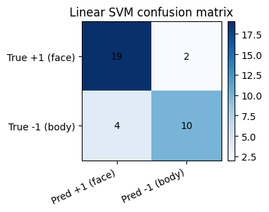

```python
# Plot confusion matrix for the linear SVM and print FP/FN to support the discussion
def plot_cm(cm, title):
    # cm is [[TP,FN],[FP,TN]] with +1 as positive
    cm_arr = np.asarray(cm, dtype=int)
    plt.figure(figsize=(3.8, 3.2))
    plt.imshow(cm_arr, cmap='Blues')
    plt.xticks([0, 1], ['Pred +1 (face)', 'Pred -1 (body)'], rotation=25, ha='right')
    plt.yticks([0, 1], ['True +1 (face)', 'True -1 (body)'])
    for i in range(2):
        for j in range(2):
            plt.text(j, i, str(cm_arr[i, j]), ha='center', va='center', color='black')
    plt.title(title)
    plt.colorbar(fraction=0.046, pad=0.04)
    plt.tight_layout()
    plt.show()

tp, fn = int(cm[0, 0]), int(cm[0, 1])
fp, tn = int(cm[1, 0]), int(cm[1, 1])
print('Linear SVM: FP=', fp, 'FN=', fn)
if fp > fn:
    print('Interpretation: model tends to over-predict +1 (face) on -1 (body) images.')
elif fn > fp:
    print('Interpretation: model tends to over-predict -1 (body) on +1 (face) images.')
else:
    print('Interpretation: FP and FN are balanced (no strong asymmetry).')

plot_cm(cm, 'Linear SVM confusion matrix')
```

# Part 2 — Kernel SVM (from scratch) + scikit-learn comparisons + analysis

## Kernel SVM background (for Part 2a and subsequent parts)

In many cases, the dataset is not linearly separable in the original feature space. Kernel SVMs address this by implicitly mapping inputs through a feature map $\phi(\cdot)$ and learning a linear separator in that (possibly high-dimensional) space.

Instead of explicitly computing $\phi(x)$, use the kernel trick via a kernel function:

$$ K(x_i, x_j) = \phi(x_i)^T\phi(x_j). $$

The soft-margin SVM dual becomes:

$$ \max_{\lambda}\ \sum_i \lambda_i - \frac{1}{2}\sum_{i,j} \lambda_i\lambda_j y_i y_j K(x_i,x_j) \quad \text{s.t. } 0 \le \lambda_i \le C,\ \sum_i \lambda_i y_i = 0. $$

The resulting decision function can be written purely in terms of kernels:

$$ f(x) = \sum_i \lambda_i y_i K(x_i, x) + b, $$

where points with $\lambda_i>0$ act as support vectors that define the classifier boundary.

```python
# Heuristic: match sklearn's default gamma='scale' for RBF/poly (common, stable baseline)

gamma_scale = 1.0 / (split.X_train.shape[1] * float(split.X_train.var() + 1e-12))

gamma_scale
```

```
0.001201923076923077
```

```python
'''
Code for kernel_svm.py
'''
from __future__ import annotations

from dataclasses import dataclass

import numpy as np


def kernel_linear(x: np.ndarray, z: np.ndarray) -> float:
    return float(np.dot(x, z))


def kernel_poly(x: np.ndarray, z: np.ndarray, gamma: float = 1.0, coef0: float = 1.0,
                degree: int = 3) -> float:
    return float((gamma * np.dot(x, z) + coef0) ** degree)


def kernel_rbf(x: np.ndarray, z: np.ndarray, gamma: float = 0.1) -> float:
    diff = x - z
    return float(np.exp(-gamma * np.dot(diff, diff)))


@dataclass
class KernelSVMModel:
    alphas: np.ndarray
    b: float
    X_train: np.ndarray
    y_train: np.ndarray
    kernel_name: str
    kernel_params: dict

    def decision_function(self, X: np.ndarray) -> np.ndarray:
        X = np.asarray(X, dtype=np.float32)
        y = self.y_train.astype(np.float32)
        a = self.alphas.astype(np.float32)

        # Compute f(x) = sum_i alpha_i y_i K(x_i, x) + b
        out = np.zeros(X.shape[0], dtype=np.float32)
        for j in range(X.shape[0]):
            s = 0.0
            xj = X[j]
            for i in range(self.X_train.shape[0]):
                if a[i] == 0.0:
                    continue
                s += a[i] * y[i] * self._K(self.X_train[i], xj)
            out[j] = s + self.b
        return out

    def predict(self, X: np.ndarray) -> np.ndarray:
        scores = self.decision_function(X)
        return np.where(scores >= 0.0, 1, -1)

    def _K(self, x: np.ndarray, z: np.ndarray) -> float:
        if self.kernel_name == "linear":
            return kernel_linear(x, z)
        if self.kernel_name == "poly":
            return kernel_poly(x, z, **self.kernel_params)
        if self.kernel_name == "rbf":
            return kernel_rbf(x, z, **self.kernel_params)
        raise ValueError(f"Unknown kernel: {self.kernel_name}")


class KernelSoftMarginSVM_SMO:
    """Binary soft-margin kernel SVM trained with a simple SMO.

    Optimizes the standard kernel SVM dual:
        max_a  sum_i a_i - 1/2 sum_{i,j} a_i a_j y_i y_j K(x_i,x_j)
        s.t.   0 <= a_i <= C, sum_i a_i y_i = 0

    """

    def __init__(
        self,
        C: float = 1.0,
        kernel: str = "rbf",
        kernel_params: dict | None = None,
        tol: float = 1e-3,
        max_passes: int = 10,
        seed: int = 0,
    ):
        self.C = float(C)
        self.kernel = str(kernel)
        self.kernel_params = dict(kernel_params or {})
        self.tol = float(tol)
        self.max_passes = int(max_passes)
        self.seed = int(seed)

    def fit(self, X: np.ndarray, y: np.ndarray) -> KernelSVMModel:
        # Use float64 for better numerical stability in SMO updates.
        X = np.asarray(X, dtype=np.float64)
        y = np.asarray(y, dtype=np.float64).reshape(-1)
        n = X.shape[0]

        rng = np.random.default_rng(self.seed)

        alphas = np.zeros(n, dtype=np.float64)
        b = 0.0

        # Precompute kernel matrix for speed (n is small here ~100).
        K = np.zeros((n, n), dtype=np.float64)
        for i in range(n):
            for j in range(n):
                K[i, j] = self._K(X[i], X[j])

        # Cache f values to avoid recomputing inner sums repeatedly.
        # f_vec[i] = sum_k alpha_k y_k K(x_k, x_i) + b
        f_vec = (alphas * y) @ K + b

        def update_f_vec(i: int, j: int, ai_old: float, aj_old: float) -> None:
            # Incremental update using delta alphas.
            dai = alphas[i] - ai_old
            daj = alphas[j] - aj_old
            if dai == 0.0 and daj == 0.0:
                return
            # f_vec[t] += dai*y_i*K(i,t) + daj*y_j*K(j,t)
            f_vec[:] = f_vec + dai * y[i] * K[i, :] + daj * y[j] * K[j, :]

        def E(i: int) -> float:
            return float(f_vec[i] - y[i])

        def select_j(i: int) -> int:
            # Heuristic: choose j that maximizes |E_i - E_j|.
            Ei = E(i)
            non_i = np.arange(n)
            # Prefer non-bound alphas for more movement.
            non_bound = np.where((alphas > 1e-8) & (alphas < self.C - 1e-8))[0]
            candidates = non_bound if non_bound.size > 1 else non_i
            j = int(candidates[np.argmax(np.abs((f_vec[candidates] - y[candidates]) - Ei))])
            if j == i:
                # fallback random different index
                j = int(rng.integers(0, n - 1))
                if j >= i:
                    j += 1
            return j

        passes = 0
        while passes < self.max_passes:
            num_changed = 0
            for i in range(n):
                Ei = E(i)

                if (y[i] * Ei < -self.tol and alphas[i] < self.C) or (y[i] * Ei > self.tol
                                                                      and alphas[i] > 0):
                    j = select_j(i)
                    Ej = E(j)

                    ai_old = float(alphas[i])
                    aj_old = float(alphas[j])

                    if y[i] != y[j]:
                        L = max(0.0, aj_old - ai_old)
                        H = min(self.C, self.C + aj_old - ai_old)
                    else:
                        L = max(0.0, ai_old + aj_old - self.C)
                        H = min(self.C, ai_old + aj_old)

                    if abs(H - L) < 1e-12:
                        continue

                    eta = 2.0 * float(K[i, j]) - float(K[i, i]) - float(K[j, j])
                    if eta >= 0:
                        continue

                    # Update alpha_j and clip
                    aj_new = aj_old - (y[j] * (Ei - Ej)) / eta
                    aj_new = float(np.clip(aj_new, L, H))
                    if abs(aj_new - aj_old) < 1e-5:
                        continue

                    # Update alpha_i
                    ai_new = ai_old + y[i] * y[j] * (aj_old - aj_new)

                    alphas[i] = ai_new
                    alphas[j] = aj_new

                    update_f_vec(i, j, ai_old, aj_old)

                    # Update b
                    b1 = b - Ei - y[i] * (ai_new - ai_old) * float(
                        K[i, i]) - y[j] * (aj_new - aj_old) * float(K[i, j])
                    b2 = b - Ej - y[i] * (ai_new - ai_old) * float(
                        K[i, j]) - y[j] * (aj_new - aj_old) * float(K[j, j])

                    if 0 < ai_new < self.C:
                        b = b1
                    elif 0 < aj_new < self.C:
                        b = b2
                    else:
                        b = 0.5 * (b1 + b2)

                    # Keep f_vec consistent after b changes.
                    f_vec[:] = (alphas * y) @ K + b

                    num_changed += 1

            passes = passes + 1 if num_changed == 0 else 0

        return KernelSVMModel(
            alphas=alphas.astype(np.float64),
            b=float(b),
            X_train=X.astype(np.float64),
            y_train=y.astype(np.float64),
            kernel_name=self.kernel,
            kernel_params=self.kernel_params,
        )

    def _K(self, x: np.ndarray, z: np.ndarray) -> float:
        if self.kernel == "linear":
            return kernel_linear(x, z)
        if self.kernel == "poly":
            return kernel_poly(x, z, **self.kernel_params)
        if self.kernel == "rbf":
            return kernel_rbf(x, z, **self.kernel_params)
        raise ValueError(f"Unknown kernel: {self.kernel}")
```

## Part 2(a) Kernel SVM (Kernel #1) from scratch — Polynomial kernel

Kernel #1 definition:

$$ K(x,z)=(\gamma x^T z + c_0)^p $$

I choose a low degree $p$ (e.g., 2) to capture simple feature interactions without extreme complexity. Training uses the SMO solver on the kernelized dual. I then report test accuracy + confusion matrix.

```
Poly kernel params: {'gamma': 0.001201923076923077, 'coef0': 1.0, 'degree': 2}
Poly test accuracy: 0.8285714285714286
Poly confusion matrix [[TP,FN],[FP,TN]]:
[[19  2]
 [ 4 10]]
```

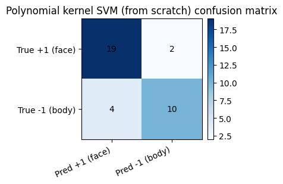

```python
poly_params = {'gamma': gamma_scale, 'coef0': 1.0, 'degree': 2}
poly_svm = KernelSoftMarginSVM_SMO(
    C=1.0, kernel='poly', kernel_params=poly_params, max_passes=80, tol=1e-3,
    seed=0
 )
poly_model = poly_svm.fit(split.X_train, split.y_train)
yhat_poly = poly_model.predict(split.X_test)

poly_acc = accuracy(split.y_test, yhat_poly)
poly_cm = confusion_matrix_binary(split.y_test, yhat_poly)

print('Poly kernel params:', poly_params)
print('Poly test accuracy:', poly_acc)
print('Poly confusion matrix [[TP,FN],[FP,TN]]:')
print(poly_cm)
plot_cm(poly_cm, 'Polynomial kernel SVM (from scratch) confusion matrix')
```

### Compare Kernel #1 vs Part 1 linear SVM (using printed test results)

- **From-scratch linear SVM**: accuracy = **0.8286**, confusion matrix = **[[19, 2], [4, 10]]**
- **Kernel #1 (polynomial, degree=2)**: accuracy = **0.8286**, confusion matrix = **[[19, 2], [4, 10]]**

**Discussion (why performance changes or does not change)**

- Performance does not change (same accuracy and identical confusion matrix).
- This suggests the handcrafted feature representation already makes the classes close to linearly separable on this split, so the polynomial kernel does not add useful extra flexibility.
- With a small dataset, different models can also end up making the same predictions on the test set when hyperparameters are in a stable range.

## Part 2(b) Kernel #2 (RBF) results and whether it improves Kernel #1

Kernel #2 definition:

$$K(x,z) = \exp\bigl(-\gamma \lVert x - z \rVert^2\bigr)$$

```
RBF params: {'gamma': 0.001201923076923077}
RBF test accuracy: 0.8285714285714286
RBF confusion matrix [[TP,FN],[FP,TN]]:
[[20  1]
 [ 5  9]]
```

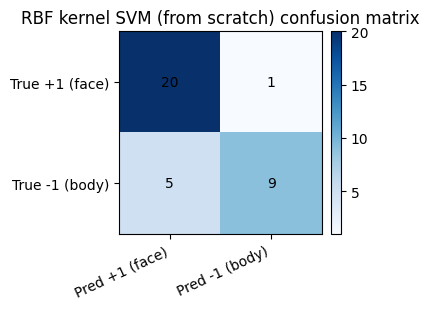

```python
rbf_params = {'gamma': gamma_scale}
rbf_svm = KernelSoftMarginSVM_SMO(
    C=1.0, kernel='rbf', kernel_params=rbf_params, max_passes=80, tol=1e-3, seed=0
 )
rbf_model = rbf_svm.fit(split.X_train, split.y_train)
yhat_rbf = rbf_model.predict(split.X_test)

rbf_acc = accuracy(split.y_test, yhat_rbf)
rbf_cm = confusion_matrix_binary(split.y_test, yhat_rbf)

print('RBF params:', rbf_params)
print('RBF test accuracy:', rbf_acc)
print('RBF confusion matrix [[TP,FN],[FP,TN]]:')
print(rbf_cm)
plot_cm(rbf_cm, 'RBF kernel SVM (from scratch) confusion matrix')
```

### Part 2(b) Discussion (using printed test results)

Using the printed test results:

- **Kernel #1 (poly, deg=2)**: accuracy = **0.8286**, CM = **[[19, 2], [4, 10]]**
- **Kernel #2 (RBF)**: accuracy = **0.8286**, CM = **[[20, 1], [5, 9]]**

**Does Kernel #2 improve Kernel #1?**

- By accuracy, no: they tie at 0.8286.
- But the error trade-off changes:
  - Poly: FN=2, FP=4
  - RBF: FN=1, FP=5
- Interpretation: RBF reduces missed faces slightly but increases false face predictions slightly, so it is not a clear improvement overall on this split.

## Part 2(c) scikit-learn SVM benchmarking (>= 3 kernels)

I benchmark scikit-learn’s `SVC` on the same features and same train/test split. Report accuracy + confusion matrix for multiple kernels and compare: (i) sklearn linear vs from-scratch linear, (ii) sklearn kernels vs from-scratch kernels, (iii) which kernel family performs best and why.

```
scratch-linear     acc=0.829  cm=[[19, 2], [4, 10]]
scratch-poly(deg2) acc=0.829  cm=[[19, 2], [4, 10]]
scratch-rbf        acc=0.829  cm=[[20, 1], [5, 9]]
sklearn-poly       acc=0.829  cm=[[19, 2], [4, 10]]
sklearn-rbf        acc=0.829  cm=[[20, 1], [5, 9]]
sklearn-linear     acc=0.771  cm=[[18, 3], [5, 9]]
sklearn-sigmoid    acc=0.743  cm=[[17, 4], [5, 9]]
```

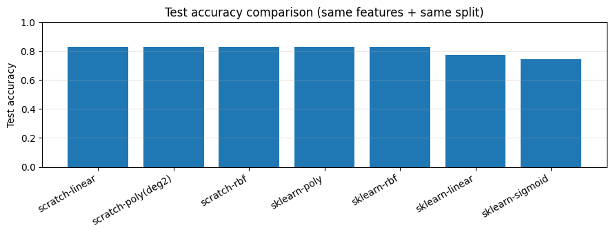

```
Best overall by accuracy: scratch-linear acc= 0.8285714285714286
```

```python
def eval_model(name, ypred):
    return {
        'model': name,
        'acc': float(accuracy(split.y_test, ypred)),
        'cm': confusion_matrix_binary(split.y_test, ypred),
    }

results = []

# from-scratch
results.append(eval_model('scratch-linear', yhat))
results.append(eval_model('scratch-poly(deg2)', yhat_poly))
results.append(eval_model('scratch-rbf', yhat_rbf))

# sklearn
sk_models = [
    ('sklearn-linear', SVC(kernel='linear', C=1.0)),
    ('sklearn-poly', SVC(kernel='poly', C=1.0, degree=2, gamma=gamma_scale,
                         coef0=1.0)),
    ('sklearn-rbf', SVC(kernel='rbf', C=1.0, gamma=gamma_scale)),
    ('sklearn-sigmoid', SVC(kernel='sigmoid', C=1.0, gamma=gamma_scale)),
]
sk_preds = {}
for name, m in sk_models:
    m.fit(split.X_train, split.y_train)
    ypred = m.predict(split.X_test)
    sk_preds[name] = ypred
    results.append(eval_model(name, ypred))

# Print a compact table
results_sorted = sorted(results, key=lambda r: (-r['acc'], r['model']))
for r in results_sorted:
    cm_here = r['cm']
    print(f"{r['model']:<18} acc={r['acc']:.3f}  cm={cm_here.tolist()}")

# Bar plot of accuracies
names = [r['model'] for r in results_sorted]
accs = [r['acc'] for r in results_sorted]
plt.figure(figsize=(9, 3.5))
plt.bar(names, accs)
plt.ylabel('Test accuracy')
plt.ylim(0, 1)
plt.xticks(rotation=30, ha='right')
plt.title('Test accuracy comparison (same features + same split)')
plt.grid(axis='y', alpha=0.3)
plt.tight_layout()
plt.show()

best_overall = results_sorted[0]
print('Best overall by accuracy:', best_overall['model'], 'acc=',
      best_overall['acc'])
```

### Part 2(c) Benchmark discussion (using the printed results)

**Printed test results (accuracy, confusion matrix [[TP,FN],[FP,TN]])**

- scratch-linear: acc = **0.829**, CM = **[[19, 2], [4, 10]]**
- scratch-poly(deg2): acc = **0.829**, CM = **[[19, 2], [4, 10]]**
- scratch-rbf: acc = **0.829**, CM = **[[20, 1], [5, 9]]**
- sklearn-linear: acc = **0.771**, CM = **[[18, 3], [5, 9]]**
- sklearn-poly: acc = **0.829**, CM = **[[19, 2], [4, 10]]**
- sklearn-rbf: acc = **0.829**, CM = **[[20, 1], [5, 9]]**
- sklearn-sigmoid: acc = **0.743**, CM = **[[17, 4], [5, 9]]**

**(i) scikit-learn vs from-scratch linear SVM**

- From-scratch linear (**0.829**) > scikit-learn linear (**0.771**) on this split.
- This is plausible because the solvers/training procedures differ; on a small dataset, solver/hyperparameter differences can noticeably affect generalization.
- sklearn-linear also runs without hyperparameter C tuning

**(ii) scikit-learn kernels vs from-scratch kernels**

- Polynomial: scikit-learn poly matches scratch poly exactly (same accuracy and CM).
- RBF: scikit-learn RBF matches scratch RBF exactly (same accuracy and CM).
- This supports that the from-scratch kernels and SMO training are consistent with scikit-learn for these settings.

**(iii) Which kernel family performs best and why?**

- Best accuracy is **0.829** and is achieved by scratch-linear, scratch-poly, scratch-rbf, sklearn-poly, and sklearn-rbf (a tie).
- This outcome is expected when the handcrafted feature representation already makes the classes close to linearly separable on this split: kernels may provide limited *accuracy* gains because there is little extra structure left to exploit.
- Even when accuracy ties, kernels can still be useful because they can change **which** borderline samples flip (here seen as a different FP/FN trade-off, e.g., RBF vs linear/poly).
- Sigmoid is worst here (**0.743**), suggesting it is not a good match for this dataset under the chosen features/hyperparameters.

## Part 2(d) Success/failure case analysis + brief summary (based on the plotted examples)

The code cell below shows representative test examples in four groups using at least two models (**scratch-linear** and **scratch-rbf** (representative best kernel), and also **sklearn-rbf** (representative best scikit-learn kernel) when available).

- Note: polynomial and RBF tie in accuracy on this split, so I use **RBF** as the representative “best kernel” for qualitative case analysis.
1. **Successful cases (both models correct)**
2. **Failure cases: linear wrong, RBF correct**
3. **Failure cases: RBF wrong, linear correct**
4. **Hard cases (both models wrong)**

**Concise failure-mode explanations grounded in visual ambiguity and feature limitations**

- **Visual ambiguity / viewpoint**: partial faces, extreme angles, and small face regions reduce stable edge patterns.
- **Background clutter dominates gradients**: strong background edges can overwhelm the gradients coming from the animal’s face/body in a HOG-like feature representation.
- **Feature limitations**: resizing/grayscale and gradient histogramming compress spatial detail; coarse pixels keep global layout but can miss fine facial landmarks.

**What I learned**

- (i) **Linear vs kernel decision boundaries**: linear SVM uses one hyperplane in feature space; kernel SVMs can represent nonlinear boundaries. Here, kernels did not improve overall accuracy over the linear model, but they changed which specific samples were misclassified.
- (ii) **Kernel choice and generalization/performance**: polynomial (deg=2) and RBF tie in accuracy (**0.8286**) on this split, implying feature quality and dataset ambiguity are dominant. RBF shifts the FP/FN trade-off (compared to poly/linear: FN 2→1, FP 4→5), consistent with a more flexible boundary that can help some borderline examples but can also be more sensitive to confusing local patterns.

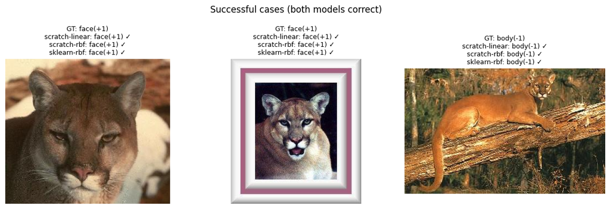

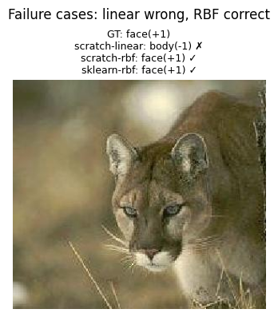

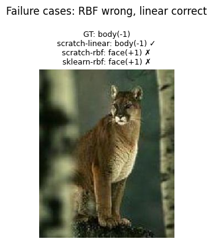

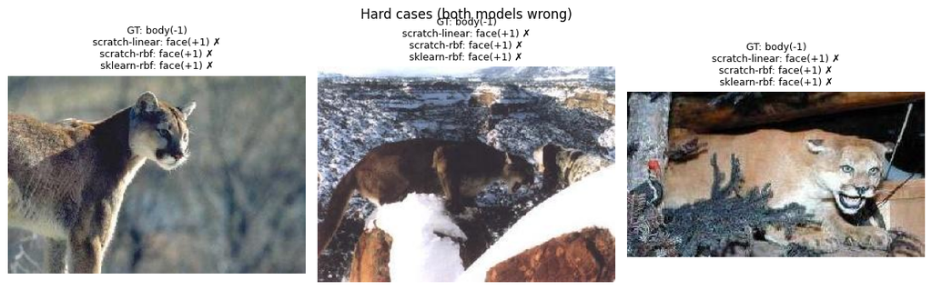

```python
# Helper: visualize a few test cases with predictions from >=2 models
def show_cases(indices, title, preds_dict):
    n = len(indices)
    plt.figure(figsize=(4 * n, 4))
    for k, idx in enumerate(indices):
        path = split.test_paths[idx]
        img = Image.open(path).convert('RGB')
        plt.subplot(1, n, k + 1)
        plt.imshow(img)
        gt = 'face(+1)' if split.y_test[idx] == 1 else 'body(-1)'
        lines = [f'GT: {gt}']
        for name, ypred in preds_dict.items():
            pr = 'face(+1)' if int(ypred[idx]) == 1 else 'body(-1)'
            ok = '✓' if int(ypred[idx]) == int(split.y_test[idx]) else '✗'
            lines.append(f'{name}: {pr} {ok}')
        plt.title('\n'.join(lines), fontsize=9)
        plt.axis('off')
    plt.suptitle(title)
    plt.tight_layout()
    plt.show()

# Compare at least two models as required
preds_compare = {
    'scratch-linear': yhat,
    'scratch-rbf': yhat_rbf,
}
if 'sklearn-rbf' in sk_preds:
    preds_compare['sklearn-rbf'] = sk_preds['sklearn-rbf']

# Choose representative examples: some where linear fails but RBF succeeds,
# and vice versa
idx_linear_wrong = set(np.where(yhat != split.y_test)[0].tolist())
idx_rbf_wrong = set(np.where(yhat_rbf != split.y_test)[0].tolist())
linear_only_wrong = sorted(list(idx_linear_wrong - idx_rbf_wrong))
rbf_only_wrong = sorted(list(idx_rbf_wrong - idx_linear_wrong))
both_wrong = sorted(list(idx_linear_wrong & idx_rbf_wrong))
both_right = sorted(list(set(range(len(split.y_test))) - (idx_linear_wrong |
                                                          idx_rbf_wrong)))

show_cases(both_right[:3], 'Successful cases (both models correct)', preds_compare)
show_cases(linear_only_wrong[:3], 'Failure cases: linear wrong, RBF correct',
           preds_compare)
show_cases(rbf_only_wrong[:3], 'Failure cases: RBF wrong, linear correct',
           preds_compare)
show_cases(both_wrong[:3], 'Hard cases (both models wrong)', preds_compare)
```

## Conclusion

- **Feature importance**: Performance is strongly affected by feature design. The HOG-like features plus coarse pixels already provide strong separability, which reduces the marginal benefit of kernels.
- **Linear vs kernel decision boundaries**: Linear SVM learns a single hyperplane; kernel SVMs can represent nonlinear boundaries through kernelized similarity. On this split, kernels did not improve overall accuracy compared to the from-scratch linear SVM, but they changed the distribution of errors.
- **Kernel choice & generalization**: Polynomial (deg=2) and RBF achieved the same test accuracy as the linear model (**0.8286**). The main difference observed is the FP/FN trade-off rather than accuracy.
- **Failure modes**: Remaining errors often come from visual ambiguity (pose, occlusion, background clutter) and from feature limitations due to resizing/grayscale and compressed representations.

## AI Use Declaration

I used ChatGPT to debug and validate on how to read images and convert each image into a fixed-length feature vector. All AI suggestions were reviewed and adapted by me, and I validated the final feature pipeline by running the notebook end-to-end and using the printed outputs reported in the analysis.

```python
'''
Code for features.py
'''
from __future__ import annotations

from dataclasses import dataclass
from pathlib import Path

import numpy as np
from PIL import Image


@dataclass(frozen=True)
class DatasetSplit:
    X_train: np.ndarray
    y_train: np.ndarray
    X_test: np.ndarray
    y_test: np.ndarray
    train_paths: list[Path]
    test_paths: list[Path]


def _list_images(folder: Path) -> list[Path]:
    exts = {".jpg", ".jpeg", ".png", ".bmp"}
    paths = [p for p in folder.rglob("*") if p.suffix.lower() in exts]
    paths.sort()
    return paths


def load_cougar_paths(root: Path) -> tuple[list[Path], list[int]]:
    face_dir = root / "cougar_face"
    body_dir = root / "cougar_body"
    if not face_dir.exists() or not body_dir.exists():
        raise FileNotFoundError(
            f"Expected {face_dir} and {body_dir} to exist. Got: {root}"
        )

    face_paths = _list_images(face_dir)
    body_paths = _list_images(body_dir)

    paths = face_paths + body_paths
    # Label convention: +1 = face, -1 = body
    labels = ([1] * len(face_paths)) + ([-1] * len(body_paths))
    return paths, labels


def _preprocess_image(
    path: Path,
    size: tuple[int, int] = (32, 32),
    grayscale: bool = True,
) -> np.ndarray:
    img = Image.open(path)
    img = img.convert("L" if grayscale else "RGB")
    img = img.resize(size, Image.BILINEAR)
    arr = np.asarray(img, dtype=np.float32)
    # Normalize pixel range to [0,1]
    arr = arr / 255.0
    return arr


def extract_features(
    paths: list[Path],
    size: tuple[int, int] = (32, 32),
    grayscale: bool = True,
    add_edge_hist: bool = True,
    edge_bins: int = 16,
) -> np.ndarray:
    """Simple fixed-length features.

    Base: flattened resized grayscale pixels.
    histogram of gradient magnitudes (captures edges/structure).

    """

    feats: list[np.ndarray] = []
    for p in paths:
        img = _preprocess_image(p, size=size, grayscale=grayscale)

        base = img.reshape(-1)
        if add_edge_hist:
            # Sobel-ish gradients via simple finite differences.
            gx = np.zeros_like(img)
            gy = np.zeros_like(img)
            gx[:, 1:-1] = img[:, 2:] - img[:, :-2]
            gy[1:-1, :] = img[2:, :] - img[:-2, :]
            mag = np.sqrt(gx * gx + gy * gy)
            # Histogram of magnitudes (normalized)
            hist, _ = np.histogram(mag, bins=edge_bins, range=(0.0, float(mag.max() + 1e-6)))
            hist = hist.astype(np.float32)
            hist = hist / (hist.sum() + 1e-12)
            feat = np.concatenate([base, hist], axis=0)
        else:
            feat = base

        feats.append(feat)

    X = np.stack(feats, axis=0)
    return X


def extract_features_hoglike(
    paths: list[Path],
    size: tuple[int, int] = (64, 64),
    pixels_downsample: tuple[int, int] = (16, 16),
    cell_size: int = 8,
    n_orient_bins: int = 9,
) -> np.ndarray:
    """Handcrafted HOG-like descriptor.

    - Resize to `size` and convert to grayscale.
    - Compute gradient magnitude + orientation.
    - Build orientation histograms per cell.
    - Concatenate with coarse downsampled pixel intensities for global context.
    """

    feats: list[np.ndarray] = []
    for p in paths:
        img = _preprocess_image(p, size=size, grayscale=True)

        # coarse pixels
        coarse = Image.fromarray((img * 255.0).astype(np.uint8), mode="L").resize(
            pixels_downsample, Image.BILINEAR
        )
        coarse = (np.asarray(coarse, dtype=np.float32) / 255.0).reshape(-1)

        # gradients
        gx = np.zeros_like(img)
        gy = np.zeros_like(img)
        gx[:, 1:-1] = img[:, 2:] - img[:, :-2]
        gy[1:-1, :] = img[2:, :] - img[:-2, :]
        mag = np.sqrt(gx * gx + gy * gy) + 1e-12

        # orientation in [0, 180)
        ori = (np.degrees(np.arctan2(gy, gx)) + 180.0) % 180.0

        h, w = img.shape
        if h % cell_size != 0 or w % cell_size != 0:
            raise ValueError("size must be divisible by cell_size")

        n_cells_y = h // cell_size
        n_cells_x = w // cell_size
        bin_width = 180.0 / n_orient_bins

        hog = np.zeros((n_cells_y, n_cells_x, n_orient_bins), dtype=np.float32)
        for cy in range(n_cells_y):
            for cx in range(n_cells_x):
                y0, y1 = cy * cell_size, (cy + 1) * cell_size
                x0, x1 = cx * cell_size, (cx + 1) * cell_size
                cell_ori = ori[y0:y1, x0:x1].reshape(-1)
                cell_mag = mag[y0:y1, x0:x1].reshape(-1)

                # soft binning to nearest bin (simple)
                bins = np.floor(cell_ori / bin_width).astype(int)
                bins = np.clip(bins, 0, n_orient_bins - 1)
                for b, m in zip(bins, cell_mag, strict=False):
                    hog[cy, cx, b] += float(m)

        hog_vec = hog.reshape(-1)
        hog_vec = hog_vec / (np.linalg.norm(hog_vec) + 1e-12)

        feat = np.concatenate([coarse, hog_vec], axis=0)
        feats.append(feat)

    return np.stack(feats, axis=0)


def standardize_train_test(
    X_train: np.ndarray, X_test: np.ndarray
) -> tuple[np.ndarray, np.ndarray, np.ndarray, np.ndarray]:
    mu = X_train.mean(axis=0, keepdims=True)
    sigma = X_train.std(axis=0, keepdims=True)
    sigma = np.where(sigma < 1e-12, 1.0, sigma)
    return (X_train - mu) / sigma, (X_test - mu) / sigma, mu, sigma


def make_split(
    root: Path,
    test_ratio: float = 0.3,
    seed: int = 0,
    feature_mode: str = "hoglike",
) -> DatasetSplit:
    paths, labels = load_cougar_paths(root)
    paths = list(paths)
    labels = np.asarray(labels, dtype=np.int64)

    rng = np.random.default_rng(seed)

    idx_face = np.where(labels == 1)[0]
    idx_body = np.where(labels == -1)[0]

    rng.shuffle(idx_face)
    rng.shuffle(idx_body)

    n_face_test = int(round(len(idx_face) * test_ratio))
    n_body_test = int(round(len(idx_body) * test_ratio))

    test_idx = np.concatenate([idx_face[:n_face_test], idx_body[:n_body_test]])
    train_idx = np.concatenate([idx_face[n_face_test:], idx_body[n_body_test:]])

    rng.shuffle(test_idx)
    rng.shuffle(train_idx)

    train_paths = [paths[i] for i in train_idx]
    test_paths = [paths[i] for i in test_idx]

    y_train = labels[train_idx]
    y_test = labels[test_idx]

    if feature_mode == "pixel_edge":
        X_train = extract_features(train_paths)
        X_test = extract_features(test_paths)
    elif feature_mode == "hoglike":
        X_train = extract_features_hoglike(train_paths)
        X_test = extract_features_hoglike(test_paths)
    else:
        raise ValueError(f"Unknown feature_mode: {feature_mode}")

    X_train, X_test, _, _ = standardize_train_test(X_train, X_test)

    return DatasetSplit(
        X_train=X_train,
        y_train=y_train,
        X_test=X_test,
        y_test=y_test,
        train_paths=train_paths,
        test_paths=test_paths,
    )
```